# Einführung in Python für Data Analytics

HWR Berlin

*Alessandro Bramucci*

# Das Programm für heute

1. Lineare Regression
2. Beta-Koeffizienten
3. Logistische Regression

# 1. Lineare Regression

- In dieser Einheit wollen wir lernen, wie man lineare Regressionen in Python mit der Bibliothek *statsmodels* durchführt (`import statsmodels.api as sm`).
- Eine lineare Regression ist ein statistisches Verfahren, das genutzt wird, um die Beziehung zwischen einer abhängigen Variable (oft auch Zielvariable oder Response-Variable genannt) und einer oder mehreren unabhängigen Variablen (auch Regressoren genannt) zu modellieren.
- Das Ziel der linearen Regression ist die Parameter (oder Koeffizienten) zu schätzen die oft mit dem griechischen Buchstaben $\beta$ bezeichnet werden.
- Die Parameter messen die Auswirkungen der Veränderung der unabhängigen Variablen auf die abhängige Variable.
- Wir haben keine Zeit, die Formeln für die Ermittlung der $\beta$-Koeffizienten zu untersuchen. Die Formeln sind in jedem Ökonometrie-Lehrbuch zu finden.
- In dieser Präsentation konzentrieren wir uns darauf, wie man Regressionen in Python schätzt, wie man Koeffizienten interpretiert und wie man Regressionen für Prognosen verwendet.

### Einfache Regression

Die einfache Regressionsanalyse wird auch als „bivariate Regression“ bezeichnet weil es nur zwei Variablen gibt, eine abhängige Variable und eine unabhängige Variable. Das Modell kann in der Form $y = \beta_0 + \beta_1 x + \epsilon$ dargestellt werden, wobei

- $y$ die abhängige Variable ist,
- $x$ die unabhängige Variable ist,
- $\beta_0$ der Achsenabschnitt (*Intercept*) ist,
- $\beta_1$ die Steigung (*Slope*) ist, die den Effekt der unabhängigen Variable auf die abhängige Variable beschreibt,
- $\epsilon$ der Fehlerterm ist, der die Abweichungen der tatsächlichen Werte von den durch das Modell vorhergesagten Werten darstellt. Es wird angenommen, dass der Fehlerterm im Durchschnitt Null ist, $E(\epsilon)=0$.
- Für diese Übung wollen wir den Datensatz *tips* aus der Biliothek *seaborn* verwenden.
- Der Datensatz enthält Informationen über Trinkgelder, die in einem Restaurant gegeben wurden, und umfasst Variablen wie die Gesamtrechnung, den Trinkgeldbetrag, das Geschlecht der Person, die die Rechnung bezahlt, ob es Raucher in der Gruppe gab, den Wochentag, die Tageszeit und die Größe der Gruppe.
- Wir möchten eine bivariate lineare Regression schätzen, die den Trinkgeldbetrag (abhängige Variable) und die Gesamtrechnung (unabhängige Variable) in Beziehung setzt.

$$\text{tip_amount} = \beta_0 + \beta_1 \text{total_bill} + \epsilon$$

- Importieren Sie die Bibliothek *seaborn*, wenn Sie die Übung replizieren möchten `import seaborn as sns`. Dann `df = sns.load_dataset("tips")`.

```
<class 'pandas.core.frame.DataFrame'>
RangeIndex: 244 entries, 0 to 243
Data columns (total 7 columns):
 #   Column      Non-Null Count  Dtype
---  ------      --------------  -----
 0   total_bill  244 non-null    float64
 1   tip         244 non-null    float64
 2   sex         244 non-null    category
 3   smoker      244 non-null    category
 4   day         244 non-null    category
 5   time        244 non-null    category
 6   size        244 non-null    int64
dtypes: category(4), float64(2), int64(1)
memory usage: 7.4 KB
```

|  | total_bill | tip | size |
| --- | --- | --- | --- |
| count | 244.000000 | 244.000000 | 244.000000 |
| mean | 19.785943 | 2.998279 | 2.569672 |
| std | 8.902412 | 1.383638 | 0.951100 |
| min | 3.070000 | 1.000000 | 1.000000 |
| 25% | 13.347500 | 2.000000 | 2.000000 |
| 50% | 17.795000 | 2.900000 | 2.000000 |
| 75% | 24.127500 | 3.562500 | 3.000000 |
| max | 50.810000 | 10.000000 | 6.000000 |

```
y = df["tip"]

X = df["total_bill"]

X = sm.add_constant(X)

model = sm.OLS(y, X).fit()

print(model.summary())
```

```
                            OLS Regression Results
==============================================================================
Dep. Variable:                    tip   R-squared:                       0.457
Model:                            OLS   Adj. R-squared:                  0.454
Method:                 Least Squares   F-statistic:                     203.4
Date:                Tue, 10 Jun 2025   Prob (F-statistic):           6.69e-34
Time:                        15:45:16   Log-Likelihood:                -350.54
No. Observations:                 244   AIC:                             705.1
Df Residuals:                     242   BIC:                             712.1
Df Model:                           1
Covariance Type:            nonrobust
==============================================================================
                 coef    std err          t      P>|t|      [0.025      0.975]
------------------------------------------------------------------------------
const          0.9203      0.160      5.761      0.000       0.606       1.235
total_bill     0.1050      0.007     14.260      0.000       0.091       0.120
==============================================================================
Omnibus:                       20.185   Durbin-Watson:                   2.151
Prob(Omnibus):                  0.000   Jarque-Bera (JB):               37.750
Skew:                           0.443   Prob(JB):                     6.35e-09
Kurtosis:                       4.711   Cond. No.                         53.0
==============================================================================

Notes:
[1] Standard Errors assume that the covariance matrix of the errors is correctly specified.
```

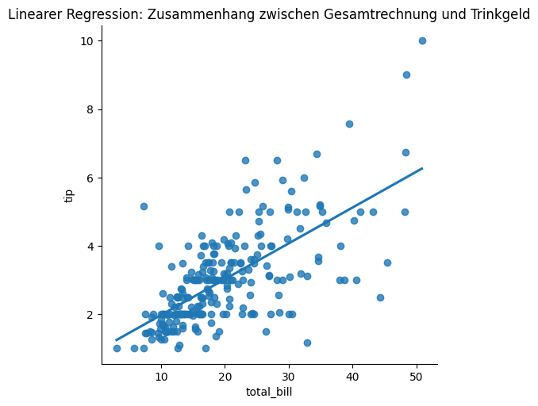

- Eine Erhöhung der Rechnung (*total_bill*) um einen Dollar bedeutet eine durchschnittliche Erhöhung des Trinkgeldes (*tip*) von $\$0,1050$.
- Wir können nun unsere geschätzten Koeffizienten verwenden, um Prognosen zu erstellen.
- Wie hoch ist das Trinkgeld, wenn die Rechnung $\$50$ beträgt?

$$0,9203 + 0,1050 \cdot 50 = 6,1703$$

- Für eine $\$50$-Rechnung können wir ein Trinkgeld von etwa $\$6,2$ erwarten.
- Nun wollen wir die gleiche Operation mit Python wiederholen (kleine Abweichungen aufgrund von Rundungsfehlern).

```
X_predict = pd.DataFrame({
    'total_bill': [50]
})

X_predict = sm.add_constant(X_predict, has_constant='add')

prediction = model.predict(X_predict)

prediction
```

```
0    6.171495
dtype: float64
```

### Multiple lineare Regression

Die multiple lineare Regression umfasst Modelle, bei denen zwei oder mehr unabhängige Variablen zur Erklärung einer abhängigen Variablen herangezogen werden. Das Modell kann in der Form $y = \beta_0 + \beta_1 x_1 + \beta_2 x_2 + ... + \beta_n x_n + \epsilon$ dargestellt werden, wobei:

- $y$ die abhängige Variable ist,
- $x_1, x_2, ..., x_n$ die unabhängigen Variablen sind,
- $\beta_0$ der Achsenabschnitt (*Intercept*) ist,
- $\beta_1, \beta_2, ..., \beta_n$ die Koeffizienten sind, die die Effekte der jeweiligen unabhängigen Variablen auf die abhängige Variable beschreiben,
- $\epsilon$ der Fehlerterm ist (Annahme $E(\epsilon)=0$).
- Nun wollen wir die Übung von oben erweitern. Diesmal fügen wir die Kontrollvariable Raucher (*smoker*) hinzu.
- Damit können wir untersuchen, ob Raucher im Durchschnitt mehr Trinkgeld geben.
- Da wir zwei unabhängige Variablen haben, werden wir drei Koeffizienten schätzen, einen Achsenabschnitt $\beta_0$ und zwei Steigungskoeffizienten $\beta_1$ und $\beta_2$.

$$\text{tip_amount} = \beta_0 + \beta_1 \text{total_bill} + \beta_2 \text{smoker} + \epsilon$$

- Zunächst müssen wir eine Dummy-Variable erstellen, die den Wert $1$ annimmt, wenn der Kunde raucht, und sonst $0$.

```
df['smoker_yes'] = df['smoker'].apply(lambda x: 1 if x == 'Yes' else 0)
```

```
y_ml = df["tip"]

X_ml = df[["total_bill", "smoker_yes"]]

X_ml = sm.add_constant(X_ml)

model_ml = sm.OLS(y_ml, X_ml).fit()

print(model_ml.summary())
```

```
                            OLS Regression Results
==============================================================================
Dep. Variable:                    tip   R-squared:                       0.459
Model:                            OLS   Adj. R-squared:                  0.455
Method:                 Least Squares   F-statistic:                     102.4
Date:                Tue, 10 Jun 2025   Prob (F-statistic):           6.57e-33
Time:                        15:45:16   Log-Likelihood:                -349.93
No. Observations:                 244   AIC:                             705.9
Df Residuals:                     241   BIC:                             716.3
Df Model:                           2
Covariance Type:            nonrobust
==============================================================================
                 coef    std err          t      P>|t|      [0.025      0.975]
------------------------------------------------------------------------------
const          0.9632      0.164      5.861      0.000       0.639       1.287
total_bill     0.1057      0.007     14.309      0.000       0.091       0.120
smoker_yes    -0.1489      0.135     -1.102      0.272      -0.415       0.117
==============================================================================
Omnibus:                       23.655   Durbin-Watson:                   2.150
Prob(Omnibus):                  0.000   Jarque-Bera (JB):               43.834
Skew:                           0.524   Prob(JB):                     3.03e-10
Kurtosis:                       4.792   Cond. No.                         57.0
==============================================================================

Notes:
[1] Standard Errors assume that the covariance matrix of the errors is correctly specified.
```

- Ähnlich wie bei der bivariaten Regression, bedeutet eine Erhöhung der Rechnung (*total_bill*) um einen Dollar eine durchschnittliche Erhöhung des Trinkgeldes (*tip*) um $\$0,1057$.
- Geben Raucher mehr Trinkgeld als Nichtraucher? Nein. Ein Raucher lässt im Durchschnitt $\$ 0,1489$ weniger Trinkgeld als ein Nichtraucher.
- Wir können nun noch eine Prognose erstellen. Diesmal können wir den Effekt einbeziehen, dass der Kunde ein Raucher ist oder nicht. Bei einer Rechnung von $\$50$ gibt ein Raucher ein Trinkgeld von:

$$0,9632 + 0,1057 \cdot 50 - 0,1489 \cdot 1 = 6,0992$$

- Ein Nichtraucher gibt ein Trinkgeld von:

$$0,9632 + 0,1057 \cdot 50 - 0,1489 \cdot 0 = 6,2482$$

- Zwischen dem Tipp von Rauchern und Nichtrauchern gibt es genau einen Unterschied von $\$0,149$ (Koeffizient der Dummy-Variable $smoker_{yes}$).
- Nun wollen wir die gleiche Operation mit Python wiederholen (kleine Abweichungen aufgrund von Rundungsfehlern).

```
X_predict_ml = pd.DataFrame({
    'total_bill': [50],
    'smoker_yes': [1]
})

X_predict_ml = sm.add_constant(X_predict_ml, has_constant='add')

prediction_ml = model_ml.predict(X_predict_ml)

prediction_ml
```

```
0    6.100419
dtype: float64
```

# 2. Beta-Koeffizienten

- Beta-Koeffizienten – auch als standardisierte Koeffizienten bezeichnet – sind Regressionskoeffizienten, die angeben, um wie viele Standardabweichungen sich die abhängige Variable verändert, wenn die unabhängige Variable um eine Standardabweichung zunimmt.
- Eine Variable wird standardisiert, indem von jeder Beobachtung zunächst der Mittelwert der Variable subtrahiert und das Ergebnis anschließend durch die Standardabweichung der Variable dividiert wird. Dadurch entstehen sogenannte $z$-scores für jede Beobachtung in der Stichprobe. Dieser Standardisierungsschritt wird sowohl für die abhängige als auch für jede unabhängige Variable durchgeführt. Dann wird eine normale OLS-Regression durchgeführt.
- Diese Umwandlung ist hilfreich, weil die Auswirkungen einer Änderung von $x_n$ auf $y$ nicht mehr in den ursprünglichen Einheiten der Variablen gemessen werden, sondern in Einheiten der Standardabweichung.
- Dadurch lassen sich die Größenordnungen der Regressionskoeffizienten direkt miteinander vergleichen, etwas das mit unveränderten Maßeinheiten nicht möglich wäre. Vereinfacht gesagt können wir so bestimmen, welche unabhängige Variable den stärksten Einfluss auf $y$ ausübt.
- Wenn es nur einen Regressor gibt, $x_1$, dann ist der standardisierte Koeffizient der Stichprobenkorrelationskoeffizient zwischen $x_1$ und $y$.

```
url = "https://www.alessandrobramucci.com/gapminder.csv"

df = pd.read_csv(url)

df.to_csv("data/gapminder.csv", sep = ",", decimal = ".")
```

```
df_2007 = df[df['year'] == 2007]

X = df_2007[['pop', 'gdpPercap']]

y = df_2007['lifeExp']

X = sm.add_constant(X)

model = sm.OLS(y, X).fit()

print(model.summary())
```

### Regression mit „normalen“ Koeffizienten

```
==============================================================================
                 coef    std err          t      P>|t|      [0.025      0.975]
------------------------------------------------------------------------------
const         59.2052      1.040     56.906      0.000      57.148      61.262
pop         7.001e-09   5.07e-09      1.381      0.169   -3.02e-09     1.7e-08
gdpPercap      0.0006   5.82e-05     11.029      0.000       0.001       0.001
==============================================================================
```

### Regression mit Beta-Koeffizienten

```
==============================================================================
                 coef    std err          t      P>|t|      [0.025      0.975]
------------------------------------------------------------------------------
const       4.094e-16      0.062   6.62e-15      1.000      -0.122       0.122
pop            0.0856      0.062      1.381      0.169      -0.037       0.208
gdpPercap      0.6834      0.062     11.029      0.000       0.561       0.806
==============================================================================
```

# 3. Logistische Regression

- Die logistische Regression ist ein statistisches Modell, das verwendet wird, um die Wahrscheinlichkeit eines Ereignisses zu modellieren, das zwei mögliche Ausgänge hat (binär).
- Im Gegensatz zur linearen Regression, die eine kontinuierliche abhängige Variable vorhersagt, wird bei der logistischen Regression eine kategorische abhängige Variable vorhergesagt, typischerweise mit zwei Klassen (z.B. Ja/Nein, Erfolg/Misserfolg).
- Die logistische Regression verwendet die logistische Funktion (auch Sigmoid-Funktion genannt), um die Wahrscheinlichkeiten zu modellieren, dass eine bestimmte Beobachtung zu einer der beiden Kategorien gehört.
- Diese Funktion hat den Vorteil, dass sie Werte zwischen 0 und 1 ausgibt, was sie ideal für Wahrscheinlichkeiten macht.
- Der Maximum-Likelihood-Verfahren wird genutzt zur Schätzung der Koeffizienten.
- Ähnlich wie bei einer linearen Regression kann die logistische Regression eine oder mehrere unabhängige Variablen haben.
- Wenn es mehrere unabhängige Variablen gibt, lautet die Regressionsgleichung

$$ln\frac{p}{1-p} = \beta_0 + \beta_1 x_1 + ... + \beta_n x_n$$

- Die linke Seite der Gleichung ist das so genannte Log-Odds-Ratio. Das ist nicht einfach zu interpretieren. Was wir leicht interpretieren können, ist die Wahrscheinlichkeit $p$. Mit etwas Manipulation erhalten wir:

$$ p = \frac{1}{1 + e^{-(\beta_0 + \beta_1 x_1 + ... + \beta_n x_n)}} $$

- $p$ ist die Wahrscheinlichkeit, dass das Ereignis eintritt, gegeben die unabhängigen Variablen $x_1, ..., x_n$.
- Für diese Übung verwenden wir einen anderen Datensatz. Der Datensatz enthält Informationen über die Noten einiger Studierende (*score*) und die Anzahl der Stunden, die die Studierende mit Lernen verbracht haben (*hours*). Wir haben auch Informationen über das Geschlecht.<sup>1</sup>
- Unser Ziel ist es, die Wahrscheinlichkeit für das Bestehen der Prüfung in Abhängigkeit von der Studienzeit zu schätzen. Wir können auch kontrollieren, ob es Unterschiede zwischen Frauen und Männern gibt.
- Vorsicht! Einige Variablen sind nicht vorhanden und müssen zuerst definiert werden.
- Wenn Sie die Übung wiederholen möchten, sollten Sie zunächst die Daten herunterladen.
1. Die Daten wurden einfach simuliert.

```
url = "https://www.alessandrobramucci.com/grades.csv"

df = pd.read_csv(url)

df.to_csv("data/grades.csv", sep = ";", decimal = ".")
```

|  | score | hours | gender |
| --- | --- | --- | --- |
| 0 | 75 | 4.0 | Male |
| 1 | 83 | 5.0 | Male |
| 2 | 55 | 3.5 | Female |
| 3 | 30 | 1.5 | Male |
| 4 | 79 | 3.0 | Female |

```
<class 'pandas.core.frame.DataFrame'>
RangeIndex: 22 entries, 0 to 21
Data columns (total 3 columns):
 #   Column  Non-Null Count  Dtype
---  ------  --------------  -----
 0   score   22 non-null     int64
 1   hours   22 non-null     float64
 2   gender  22 non-null     object
dtypes: float64(1), int64(1), object(1)
memory usage: 656.0+ bytes
```

|  | score | hours |
| --- | --- | --- |
| count | 22.000000 | 22.000000 |
| mean | 53.909091 | 4.000000 |
| std | 30.885208 | 2.079606 |
| min | 10.000000 | 0.000000 |
| 25% | 24.750000 | 2.812500 |
| 50% | 51.000000 | 3.875000 |
| 75% | 83.000000 | 5.375000 |
| max | 95.000000 | 8.000000 |

- Wir definieren eine Variable Bestanden (*passed*), wenn die Studierende die Prüfung bestanden hat. Die Variable nimmt den Wert $1$ an, wenn die Bewertung (*score*) größer oder gleich 50 ist.

```
df['passed'] = df['score'].apply(lambda x: 1 if x >= 50 else 0)
```

- Wir erstellen zudem eine Variable *male*, die den Wert 1 erhält, wenn die Studierende männlich ist, und 0, wenn nicht.

```
df['male'] = df['gender'].apply(lambda x: 1 if x == 'Male' else 0)
```

- Dann führen wir eine logistische Regression durch, bei der die abhängige Variable *passed* und die unabhängigen Variablen *hours* und *male* sind.

|  | score | hours | gender | passed | male |
| --- | --- | --- | --- | --- | --- |
| 0 | 75 | 4.0 | Male | 1 | 1 |
| 1 | 83 | 5.0 | Male | 1 | 1 |
| 2 | 55 | 3.5 | Female | 1 | 0 |
| 3 | 30 | 1.5 | Male | 0 | 1 |
| 4 | 79 | 3.0 | Female | 1 | 0 |

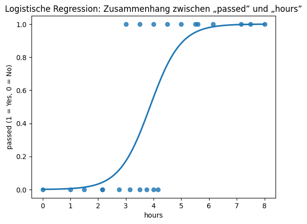

```
y_lg = df["passed"]

X_lg = df[["hours", "male"]]

X_lg = sm.add_constant(X_lg)

model_lg = sm.Logit(y_lg, X_lg).fit()

print(model_lg.summary())
```

```
Optimization terminated successfully.
         Current function value: 0.298158
         Iterations 8
                           Logit Regression Results
==============================================================================
Dep. Variable:                 passed   No. Observations:                   22
Model:                          Logit   Df Residuals:                       19
Method:                           MLE   Df Model:                            2
Date:                Tue, 10 Jun 2025   Pseudo R-squ.:                  0.5698
Time:                        15:45:17   Log-Likelihood:                -6.5595
converged:                       True   LL-Null:                       -15.249
Covariance Type:            nonrobust   LLR p-value:                 0.0001683
==============================================================================
                 coef    std err          z      P>|z|      [0.025      0.975]
------------------------------------------------------------------------------
const         -6.9745      3.661     -1.905      0.057     -14.150       0.201
hours          2.0119      0.999      2.014      0.044       0.054       3.970
male          -1.5885      1.475     -1.077      0.282      -4.480       1.303
==============================================================================
```

- Wie hoch ist die Wahrscheinlichkeit, dass ein männlicher Student, der 4 Stunden gelernt hat, die Prüfung erfolgreich besteht?

```
X_predict = pd.DataFrame({
    'hours': [4],
    'male': [1]
})

X_predict = sm.add_constant(X_predict, has_constant='add')

predicted_probability = model_lg.predict(X_predict)

print(predicted_probability)
```

```
0    0.373873
dtype: float64
```

- Hat das Modell erfolgreich vorhergesagt, ob Studierende die Prüfung bestanden haben?
- Eine Konfusionsmatrix (oder Fehlermatrix) ist eine Visualisierungsmethode für die Ergebnisse von Klassifizierungsalgorithmen.
- Genauer gesagt handelt es sich um eine Tabelle, die die Anzahl der Instanzen einer bestimmten Klasse mit der Anzahl der vorhergesagten Klasseninstanzen vergleicht.
- Es gibt insgesamt vier Ergebnisse:
  - **True Positive (TP)**: Die Studierende hat die Prüfung bestanden, und das Modell hat das Bestehen vorhergesagt.
  - **False Positive (FP)**: Die Studierende hat die Prüfung nicht bestanden, aber das Modell hat das Bestehen vorhergesagt.
  - **True Negative (TN)**: Die Studierende hat die Prüfung nicht bestanden, und das Modell hat das Nichtbestehen vorhergesagt.
  - **False Negative (FN)**: Die Studierende hat die Prüfung bestanden, aber das Modell hat das Nichtbestehen vorhergesagt.

|  | Vorhergesagt 0 | Vorhergesagt 1 |
| --- | --- | --- |
| Tatsächlich 0 | True negative (TN) | False positive (FP) |
| Tatsächlich 1 | False negative (FN) | True positive (TP) |

- Wie hat unser Modell abgeschnitten?

|  | Vorhergesagt 0 | Vorhergesagt 1 |
| --- | --- | --- |
| Tatsächlich 0 | 9.0 | 2.0 |
| Tatsächlich 1 | 2.0 | 9.0 |

- Um die Konfusionsmatrix richtig zu verstehen, ist es entscheidend, die wichtigsten Metriken zu kennen, die zur Bewertung der Modellleistung herangezogen werden. 📘[Link](https://www.datacamp.com/de/tutorial/what-is-a-confusion-matrix-in-machine-learning)
- Genauigkeit (*accuracy*): Die Genauigkeit entspricht dem Anteil korrekt klassifizierter Fälle an der Gesamtzahl aller betrachteten Fälle.

$$\text{Genauigkeit} = \frac{TP + TN}{TP +TN + FP + FN}$$

- Rückruf/Empfindlichkeit (*Recall/Sensitivity*): Der Rückruf/Empfindlichkeit gibt den Anteil der korrekt erkannten positiven Fälle an, bezogen auf die Gesamtzahl aller tatsächlich positiven Fälle.

$$\text{Rückruf/Empfindlichkeit} = \frac{TP}{TP + FN} \space\space\text{oder}\space\space \frac{\text{True Positive}}{\text{Actual Results}}$$

- Präzision (*precision*): Die Präzision gibt den Anteil der korrekt vorhergesagten positiven Ergebnisse an, bezogen auf alle als positiv vorhergesagten Fälle.

$$\text{Präzision} = \frac{TP}{TP + FP} \space\space\text{oder}\space\space \frac{\text{True Positive}}{\text{Predictive Results}}$$

- Spezifität (*specificity*): Die Spezifität gibt den Anteil der korrekt erkannten negativen Fälle an, bezogen auf die Gesamtzahl aller tatsächlich negativen Fälle.

$$\text{Spezifität} = \frac{TN}{TN + FP}$$

- F1-Score: Der F1-Score bietet einen (harmonischen) Mittelwert zwischen Präzision und Recall. Der F1-Score ist nützlich, wenn eine unausgewogene Klassenverteilung vorliegt.

$$\text{F1-Score} = \frac{\text{2*Rückruf*Präzision}}{\text{Rückruf + Präzision}}$$

- Nun wollen wir die zuvor betrachteten Indikatoren (Genauigkeit, Rückruf, Präzision, Spezifität, F1-Score) mit einem neuen Logit-Modell berechnen.
- Zu diesem Zweck verwenden wir den Datensatz *Titanic*, einen Datensatz über die Passagiere der Titanic, einschließlich Alter, Klasse, Geschlecht usw.
- Mit dem Logit-Modell können wir vorhersagen, ob die Passagiere überlebt hätten oder nicht.
- Wie oben, importieren Sie die Bibliothek *seaborn*, wenn Sie die Übung replizieren möchten `import seaborn as sns`. Dann `df_titanic = sns.load_dataset("titanic")`.
- Um eine genauere Vorstellung von den Variablen des Datensatzes zu erhalten, konsultieren Sie bitte die entsprechenden Quellen. 📘[Link](https://www.kaggle.com/c/titanic/data)
- Wir werden die Analyse in vier Schritten durchführen: Daten einlesen, Daten bereinigen und Regressionsanalyse mithilfe des Logit-Modells. Anschließend berechnen wir die Indikatoren, um die Güte des Modells zu bewerten.

|  | survived | pclass | sex | age | sibsp | parch | fare | embarked | class | who | adult_male | deck | embark_town | alive | alone |
| --- | --- | --- | --- | --- | --- | --- | --- | --- | --- | --- | --- | --- | --- | --- | --- |
| 0 | 0 | 3 | male | 22.0 | 1 | 0 | 7.2500 | S | Third | man | True | NaN | Southampton | no | False |
| 1 | 1 | 1 | female | 38.0 | 1 | 0 | 71.2833 | C | First | woman | False | C | Cherbourg | yes | False |
| 2 | 1 | 3 | female | 26.0 | 0 | 0 | 7.9250 | S | Third | woman | False | NaN | Southampton | yes | True |
| 3 | 1 | 1 | female | 35.0 | 1 | 0 | 53.1000 | S | First | woman | False | C | Southampton | yes | False |
| 4 | 0 | 3 | male | 35.0 | 0 | 0 | 8.0500 | S | Third | man | True | NaN | Southampton | no | True |
| 5 | 0 | 3 | male | NaN | 0 | 0 | 8.4583 | Q | Third | man | True | NaN | Queenstown | no | True |
| 6 | 0 | 1 | male | 54.0 | 0 | 0 | 51.8625 | S | First | man | True | E | Southampton | no | True |
| 7 | 0 | 3 | male | 2.0 | 3 | 1 | 21.0750 | S | Third | child | False | NaN | Southampton | no | False |
| 8 | 1 | 3 | female | 27.0 | 0 | 2 | 11.1333 | S | Third | woman | False | NaN | Southampton | yes | False |
| 9 | 1 | 2 | female | 14.0 | 1 | 0 | 30.0708 | C | Second | child | False | NaN | Cherbourg | yes | False |

- Anzahl der Zeilen und Spalten

```
(891, 15)
```

- Übersicht zum Datensatz

```
<class 'pandas.core.frame.DataFrame'>
RangeIndex: 891 entries, 0 to 890
Data columns (total 15 columns):
 #   Column       Non-Null Count  Dtype
---  ------       --------------  -----
 0   survived     891 non-null    int64
 1   pclass       891 non-null    int64
 2   sex          891 non-null    object
 3   age          714 non-null    float64
 4   sibsp        891 non-null    int64
 5   parch        891 non-null    int64
 6   fare         891 non-null    float64
 7   embarked     889 non-null    object
 8   class        891 non-null    category
 9   who          891 non-null    object
 10  adult_male   891 non-null    bool
 11  deck         203 non-null    category
 12  embark_town  889 non-null    object
 13  alive        891 non-null    object
 14  alone        891 non-null    bool
dtypes: bool(2), category(2), float64(2), int64(4), object(5)
memory usage: 80.7+ KB
```

- Für diese Übung benötigen wir nicht alle Variablen. Wir behalten nur *survived*, unsere abhängige Variable, *pclass*, *sex*, und *age* (unabhängige Variablen).

```
df_titanic_new = df_titanic[['survived', 'pclass', 'sex', 'age']]

df_titanic_new.head()
```

|  | survived | pclass | sex | age |
| --- | --- | --- | --- | --- |
| 0 | 0 | 3 | male | 22.0 |
| 1 | 1 | 1 | female | 38.0 |
| 2 | 1 | 3 | female | 26.0 |
| 3 | 1 | 1 | female | 35.0 |
| 4 | 0 | 3 | male | 35.0 |

- Wie viele fehlende Werte gibt es im Datensatz?

```
df_titanic_new.isnull().sum()
```

```
survived      0
pclass        0
sex           0
age         177
dtype: int64
```

- Wir ersetzen die fehlenden Werte in der Variablen *age* durch den Modalwert (alternativ könnten wir die Zeilen mit den fehlenden Werten entfernen. Wir würden aber viele Beobachtungen verlieren).

```
age_modalwert = df_titanic_new['age'].mode()[0]

df_titanic_new['age'] = df_titanic_new['age'].fillna(age_modalwert)

df_titanic_new.isnull().sum()
```

```
survived    0
pclass      0
sex         0
age         0
dtype: int64
```

- Jetzt müssen wir die Dummy-Variablen für *pclass* und *sex* erstellen. Anschließend fügen wir die neuen Variablen zum vorherigen Datensatz hinzu.

```
d_sex_male = pd.get_dummies(df_titanic_new['sex'], drop_first = True) # Drop female

d_class_23 = pd.get_dummies (df_titanic_new['pclass'], drop_first = True) # Drop first class

df_titanic_final = pd.concat([df_titanic_new, d_sex_male, d_class_23], axis = 1)

df_titanic_final1 = df_titanic_final.drop(columns = ['sex', 'pclass'])

df_titanic_final2 = df_titanic_final1.rename(columns = {2: '2class', 3: '3class'})
```

|  | survived | age | male | 2class | 3class |
| --- | --- | --- | --- | --- | --- |
| 0 | 0 | 22.0 | 1 | 0 | 1 |
| 1 | 1 | 38.0 | 0 | 0 | 0 |
| 2 | 1 | 26.0 | 0 | 0 | 1 |
| 3 | 1 | 35.0 | 0 | 0 | 0 |
| 4 | 0 | 35.0 | 1 | 0 | 1 |
| ... | ... | ... | ... | ... | ... |
| 886 | 0 | 27.0 | 1 | 1 | 0 |
| 887 | 1 | 19.0 | 0 | 0 | 0 |
| 888 | 0 | 24.0 | 0 | 0 | 1 |
| 889 | 1 | 26.0 | 1 | 0 | 0 |
| 890 | 0 | 32.0 | 1 | 0 | 1 |

891 rows × 5 columns

- Wir sind nun bereit für die logistische Regression.

```
y_lg_titanic = df_titanic_final2["survived"]

X_lg_titanic = df_titanic_final2[["age", "male", "2class", "3class"]]

X_lg_titanic = sm.add_constant(X_lg_titanic)

model_lg_titanic = sm.Logit(y_lg_titanic, X_lg_titanic).fit()

summary = model_lg_titanic.summary()

print(summary.tables[1].as_text())
```

```
Optimization terminated successfully.
         Current function value: 0.452617
         Iterations 6
==============================================================================
                 coef    std err          z      P>|z|      [0.025      0.975]
------------------------------------------------------------------------------
const          3.4700      0.358      9.703      0.000       2.769       4.171
age           -0.0321      0.007     -4.380      0.000      -0.046      -0.018
male          -2.6125      0.186    -14.017      0.000      -2.978      -2.247
2class        -1.0936      0.256     -4.270      0.000      -1.596      -0.592
3class        -2.3358      0.242     -9.636      0.000      -2.811      -1.861
==============================================================================
```

```
actual_response = df_titanic_final2["survived"]

predicted_response = np.round(model_lg_titanic.predict())

outcomes = pd.DataFrame({"actual_response": actual_response,
                         "predicted_response": predicted_response})

conf_matrix = pd.crosstab(outcomes['actual_response'],
                          outcomes['predicted_response'],
                          rownames = ['Actual'],
                          colnames = ['Predicted'])

print(conf_matrix)
```

```
Predicted  0.0  1.0
Actual
0          457   92
1           99  243
```

```
TN = conf_matrix.loc[0,0]
TP = conf_matrix.loc[1,1]
FN = conf_matrix.loc[1,0]
FP = conf_matrix.loc[0,1]

accuracy = (TN + TP) / (TN + FN + FP + TP)
print("Genauigkeit: ", np.round(accuracy, 3))

sensitivity = TP / (TP + FN)
print("Rückruf/Empfindlichkeit: ", np.round(sensitivity, 3))

precision = TP / (TP + FP)
print("Präzision: ", np.round(precision, 3))

specificity = TN / (TN + FP)
print("Spezifität: ", np.round(specificity, 3))

f1 = (2 * precision * sensitivity) / (precision + sensitivity)
print("F1-Score: ", np.round(f1, 3))
```

```
Genauigkeit:  0.786
Rückruf/Empfindlichkeit:  0.711
Präzision:  0.725
Spezifität:  0.832
F1-Score:  0.718
```

Vielen Dank für Ihre Aufmerksamkeit!🐍